# chapter 3

Imani Russell and Bart DiFiore

4/21/2021

*This section is the most technical in the book* (so bear with us... We're so glad we volunteered...)

## Brief review

As a general reminder, an IPM takes the form
$$k(z',z) = P(z',z) + F(z',z)$$

Conceptually, we are trying to predict the population size at some time $t+1$ based on the probability that an individual survives, grows, or reproduces. Here,

- $z$ is the size of an individual at time $t$
- $z'$ is the size at time $t+1$
- $P(z',z)$ is the probability that an individual survives to time $t+1$ with a body size in the class $[z',z'+h]$. **Important**: remember that $h$ represents the width of the size bin. As $h \rightarrow 0$ $n(z,t)h$ is the number of individuals with size $z$.
- $F(z',z)$ is the number of new offspring in the interval $[z′, z′ + h]$ present at time $t + 1$, per size-$z$ individual at time $t$.

Ok, so $P(z',z)$ represents "survival" and $F(z',z)$ represents "fecundity" or "reproduction". In order to survive into the next size class $z'$, you need to survive the current size class while also growing into the next size class. Therefore, $P(z',z) = s(z)G(z',z)$, where $s$ is the probabiltiy of surviving size class $z$, and $G$ is the probability that you survive into the next size class.

Ok, so if we put this all together. The number of individuals in size class $z'$ at time $t+1$ is the sum of the contributions of each individual at time $t$, or:

$$n(z',t + 1) = \int K(z',z)n(z,t)dz$$

## What is this chapter all about? Why do we care?

Generally, as IPM will allow us to learn something about how structured populations change with time. In particularly, we can determine how many individuals will exist in each state at some time in the future. As Tatum reviewed we can use an IPM to estimate $\lambda$, or the *long-term population growth rate*. And as Taom covered we can use an IPM to estimate $R0$, or the *long-term per-generation rate of increase*. While we are often interested in population level parameters, an IPM is modeling the dyanics of individuals in a particular state being born and dying. Therefore, we can use an IPM to address questions relating to the probable fate of the individual. For instance, we can use the IPM to estimate

- the probability that an individual survives to a given age
- the average age or size of an individual at death
- various metrics related to when and how much an individual reproduces

### Discussion

*Why do you think these demographic paramters matter? Can you think of questions in your own system where answering these questions would be important?*

## 3.3 Case study 1B: Monocarp life cycle properties and events

To try and simplify the code for this chapter a bit, we are going to try to use the Monocarp population as a case study to ask

1. What is the monocarp populations $\lambda$ and $R0$?
2. What is the probability of surviving to age $a$?
3. What is the mean and variance in size of a individual at death?
4. What is the mean and variance for the total reproductive output of an individual?

We've modified things a bit from the books analysis. Our code is organized according to the questions listed above.

The kernal for the monocarp population is:
$$K(z',z) = (1 - p_b(z))s(z)G(z',z) + p_b(z)b(z)p_rc_0(z')$$

where

- $p_b$ is the probability that an individual flowers
- $p_r$ is the probability that a seedling recruits
- $b(z)$ is the number of seeds produced for a plant of size $z$
- $c_0(z')$ is the offspring size distribution at time $t+1$

So we have our population, now we run the IPM using our known parameter values.

```r
nBigMatrix <- 250;

min.size <- with(sim.data, min(z)) # find minimum size
max.size <- with(sim.data, max(z)) # find maximum size

# construct iteration matrix
IPM.true <- mk_K(nBigMatrix, m.par.true, -3.5, 5.5) # +2 sd

meshpts <- IPM.true$meshpts # create vector of the meshpts in the iteration matrix - meshpts are the average(?) size for each age class?
h <- diff(meshpts)[1] # return difference between consecutive meshpts (tell us they are all evenly spaced? is this just a check for the matrix)
```

### Question 1. What is the monocarp populations $\lambda$ and $R0$?

```r
# get the dominant eigenvalue
lambda0 <- Re(eigen(IPM.true$K,only.values = TRUE)$values[1]) #only.values = TRUE specifies to only calculate eigenvalues (not eigenvectors)
lambda0
```

```
## [1] 1.068577
```

```r
fit.pop.growth <- lm(log(pop.size.t[-(1:10)])~c(11:yr))
lambda.hat <- exp(coef(fit.pop.growth)[2])
# is the simulated data still the IBM here?
cat("Growth rate: IPM ",lambda0,"True",lambda.hat, "\n")
```

```
## Growth rate: IPM  1.068577 True 1.072947
```

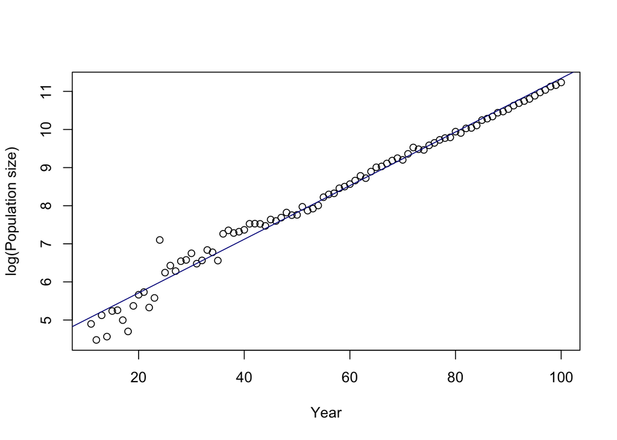

```r
# Plot it up
plot(log(pop.size.t[-(1:10)])~c(11:yr), xlab = "Year", ylab = "log(Population size)")
abline(fit.pop.growth, col = "darkblue")
```

The calculation of $R0$ is slighly more difficult. If you recall Taom's beautiful slides $R0$ is the long-term per generation increase in the population. To estimate $R0$ we are going to multiply the reproduction kernal ($F$) by the *fundamental matrix* $N$, where $N = (I-P)^{-1}$. The resulting kernal, $R$ is the "next generation kernal". $R(z′,z)h$ is an individual’s expected lifetime production of offspring with size at birth in $(z′,z′+h)$, conditional on the individual’s initial size $z$.

```r
# define the iteration matricies
P <- IPM.true$P # survival iteration matrix
F <- IPM.true$F # fecundity iteration matrix

# calculate fundamental matrix (fundamental operator )
N <- solve(diag(nBigMatrix)-P) # find probability of dying
# diag(nBigMatrix) creates ID matrix (I)
# solve inverts (I-P) matrix

R <- F %*% N # R = kernel -> projects the population from 1 generation to the next

R0 <- abs(eigen(R)$values[1]) # calc dominant eigenvalue of R
cat("R0=",R0,"\n")
```

```
## R0= 1.314787
```

In our specific IPM for monocarps, offspring size is independent of parental size. Therefore, we can calculate $R_0$ by averaging per-capita fecundity with respect to size at birth. You can see that both techniques result in the same estimate of $R0$. To do this calculation we need to integrate across the $R$ matrix, or in other words we need to sum each of the columns in the $R$ matrix. We can use a nifty trick of matrix algebra to do the summation. To see whats going on, here is a simple example.

```r
p.temp <- matrix(c(1,3,2,6), nrow = 2)
p.temp
```

```
##      [,1] [,2]
## [1,]    1    2
## [2,]    3    6
```

```r
e.temp <- matrix(1,nrow=1,ncol=dim(p.temp)[1])
e.temp
```

```
##      [,1] [,2]
## [1,]    1    1
```

```r
e.temp %*% p.temp
```

```
##      [,1] [,2]
## [1,]    4    8
```

And here we use this technique to estimate $R0$ assuming that offspring size in independent of parental size.

```r
# Define a probability distribution for offspring sizes
offspring.prob <- h*c_0z1(meshpts,m.par.true) # integrate h = width of bin
#sum(offspring.prob); # should be 1, and it is.

#Define the e vector which we will use - calc sum of each column (250 columns)
e <- matrix(1,nrow=1,ncol=dim(P)[1]) # P=survival iteration matrix
# returns a vector
# With mixing at birth, we can calculate R0 directly as the
# mean per-capita lifetime fecundity across a birth cohort
R0 <- sum((e %*% R) * offspring.prob)
cat("R0=",R0,"\n");
```

```
## R0= 1.314782
```

### Question 2. What is the probability of surviving to age $a$?

Your probability of surviving to age $a$ will depend on your size at birth $z_0$. Let $l_a$ represent survivorship to age $a$. The probability that you survive will be the probability that you survive the first year times the probability you survive the second and so on, summed across all possible size. Therefore,

$$l_a(z_0) = \int{Z} P^a(z', z_0)dz'$$

To do this in R we will need to raise the survival kernal $P$ to the power $a$ and then sum (i.e. integrate) across all the sizes.

```r
# alive means you didn't flower or die (Repr==0 & Surv==1), so this gives the probability of survival at each age
s1 <- summaryBy(alive~age,data=sim.data)

# #How many individuals in each age class?
s2 <- summaryBy(alive~age,FUN=length,data=sim.data)
# #So we have plenty up to about age 5

# create empty vector to hold survivorship curve
# la is the probability of surviving to age a
la <- rep(NA,20)

# calculate la[1], survival of age 0 individuals to age 1
la[1] <- sum((e %*% P) * offspring.prob)
la
```

```
##  [1] 0.3400957        NA        NA        NA        NA        NA        NA
##  [8]        NA        NA        NA        NA        NA        NA        NA
## [15]        NA        NA        NA        NA        NA        NA
```

To generalize for other age classes, we need to calculate $P_{a}$ = $a^{th}$ power of matrix $P$:

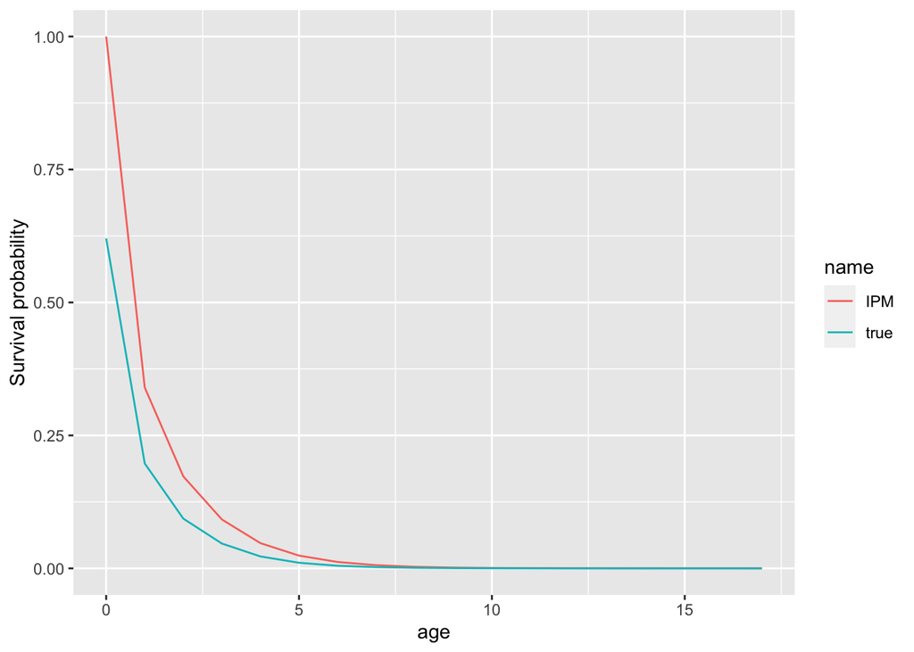

```r
#Later survivorships require P^a so let's do the calculation recursively
Pa <- P
a <- 2

for(a in 2:20){
    Pa <- Pa %*% P # why is this changing?
    Pa[1,1]
    la[a] <- sum((e %*% Pa) * offspring.prob)
    la[a]
}

la <- c(1,la)

#plot(la ~ c(1:21))

library(tidyverse)
total = dim(sim.data)[1]
sim.data %>% group_by(age) %>%
  filter(alive = TRUE) %>%
  summarize(count = n()) %>%
  mutate(true = count / total,
         IPM = la[1:18]) %>%
  pivot_longer(cols = c(true, IPM)) %>%
  ggplot(aes(x = age, y = value))+
    geom_line(aes(color = name))+
    labs(y = "Survival probability", x = "age")
```

IPM predicts higher survival probability than the truth until a little after age 5. Prediction starts at 100% for age 0 and quickly declines.

### Question 3. What is the mean and variance in the size at death?

We may be interested in understanding at what size individuals tend to die in a population.

$$\Omega(z',z) = (1-s(z'))N(z',z)$$

$\Omega$ represents the distribution of sizes at which individuals die. We've skipped the derivation here, but check out where this equation comes from at pages 66-69. In the monocarp casestudy you die when you flower, and if you don't flower you die with a probability based on your current size $1-s(z)$. Therefore, in our case

$$\Omega(z',z) = [p_b(z',z) + (1-p_b(z',z))*(1-s(z))]N(z',z)$$

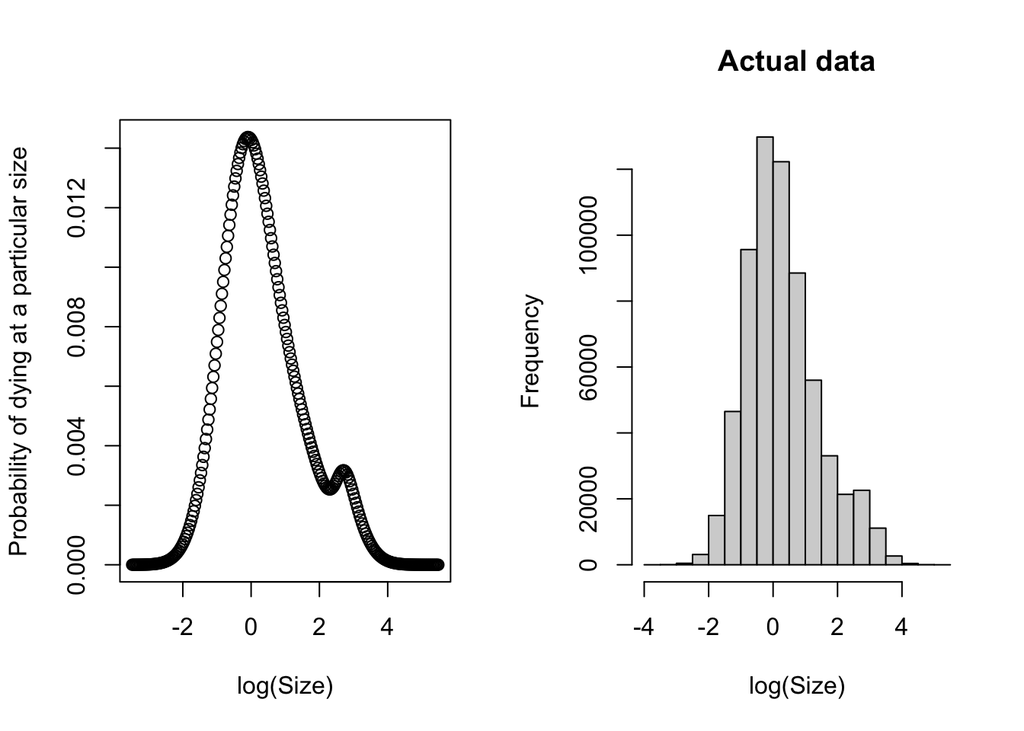

```r
Omega <- (p_bz(meshpts,m.par.true) + (1-p_bz(meshpts,m.par.true))*(1-s_z(meshpts,m.par.true))) * N

#  how can you die? You flower with probability p_bz, and if you don't
#  flower (1-p_bz) you die with probability (1-s_z)

# each of the columns defines a probability distribution and so should sum to 1, let's check
#round(e %*% Omega,4)
#all 1's as it should be.

# then the distribution of sizes at death for the offspring distribution is
dist.size.death <- (Omega %*% offspring.prob)

# again this should be a probability distribution and so sum to 1, let's check
#round(e %*% dist.size.death,4)
# so it's all good, let's calculate some moments

# 1st the mean is
mean.size.death <-round(sum(dist.size.death*meshpts),4)
mean.size.death.sim <- round(with(sim.data,mean(z[alive==0])),4)
d <- par(mfrow = c(1,2))
plot(dist.size.death~meshpts, xlab = "log(Size)", ylab = "Probability of dying at a particular size")
hist(sim.data$z[sim.data$alive == 0], xlab = "log(Size)", main = "Actual data")
```

```r
par(d)
# 2nd the variance is
Var.size.death <- round(sum(dist.size.death*meshpts*meshpts) -
          sum(dist.size.death*meshpts)*sum(dist.size.death*meshpts),4)

Var.size.death.sim <- round(with(sim.data,var(z[alive==0])),4)

# compare simulation to theory
cat("Size at death","\n")
```

```
## Size at death
```

```r
cat("Theory: mean=",mean.size.death, " variance=",Var.size.death,"\n")
```

```
## Theory: mean= 0.3505  variance= 1.3466
```

```r
cat("Simulation: mean=",mean.size.death.sim, " variance=",Var.size.death.sim,"\n")
```

```
## Simulation: mean= 0.2872  variance= 1.2662
```

```r
# very close to each other!
```

### Question 4. What is the mean and variance for the total number of recruits produced by an individual?

To figure out how many recruits an individual will produce we need to first determine the relationship between how large an individual is and when it reproduces. Because monocarps die at first reproduction, we can use the kernal $P(z',z)$ to estimate the size distribution of individuals who survive without breeding.

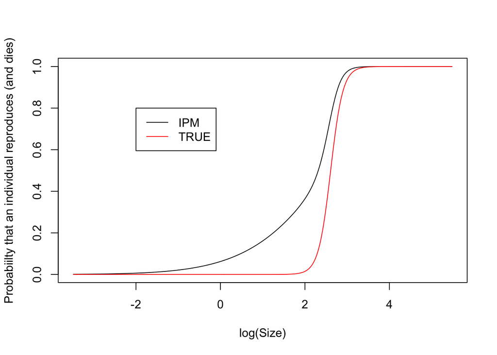

```r
#As reproduction is fatal the P kernel is the required P0 kernel
P0 <- P
N0 <- solve(diag(nBigMatrix)-P0)

#So B is given by
B <- p_bz(meshpts,m.par.true) %*% N0 #probabilities of breeding at least once

plot(meshpts,B,type="l", ylab = "Probabiilty that an individual reproduces (and dies)", xlab = "log(Size)")
points(meshpts,p_bz(meshpts,m.par.true),type="l",col="red")
legend(x = -2, y = 0.8, legend = c("IPM", "TRUE"), col = c("black", "red"), lty = c(1,1))
```

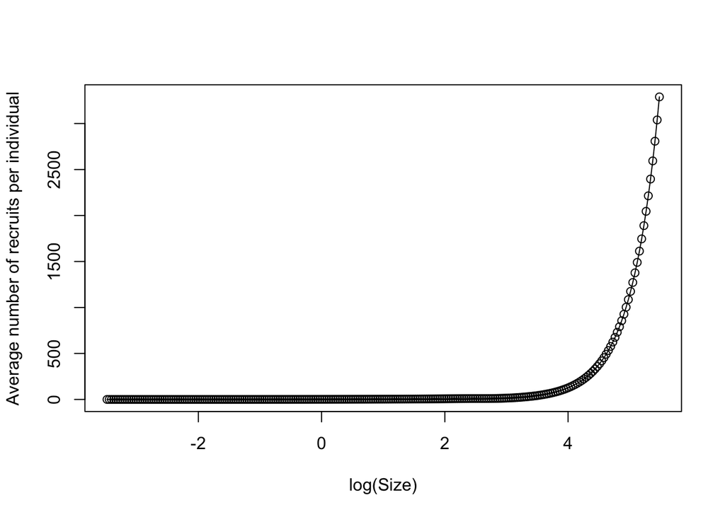

```r
#Variance in life-time reproductive output
#For a Poisson distribution the mean equals the variance, so for the number of recruits (not seeds)

# "TRUE" parameters
mean.recs <-  p_bz(meshpts,m.par.true) * m.par.true["p.r"] *  b_z(meshpts,m.par.true)
#plot(mean.recs ~ meshpts)

sigma.b.2 <-  mean.recs + (1 - p_bz(meshpts,m.par.true)) * mean.recs * mean.recs / p_bz(meshpts,m.par.true)

# Parmaters from the IPM
rbar <- e %*% R # how many recruits you produce is contingent on your initial size therefore F*N = R
#hist(as.vector(rbar))
plot(as.vector(rbar) ~ meshpts, ylab = "Average number of recruits per individual", xlab = "log(Size)")
lines(mean.recs ~ meshpts)
```

```r
r2 <- (sigma.b.2 + (m.par.true["p.r"] * p_bz(meshpts,m.par.true) * b_z(meshpts,m.par.true))^2) %*% N
var.b <- r2 - rbar*rbar

#plot(as.vector(var.b) ~ meshpts)
```